# Case Study - 10

## 13.2 Holt’s linear trend method

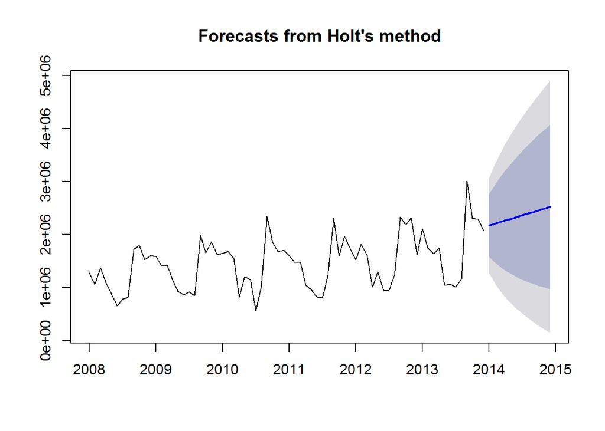

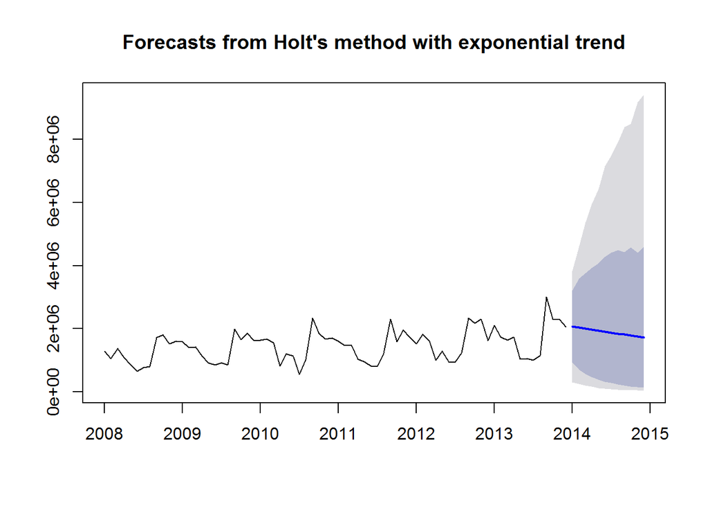

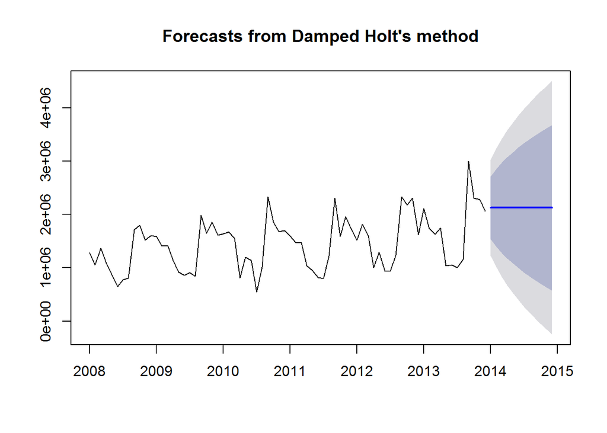

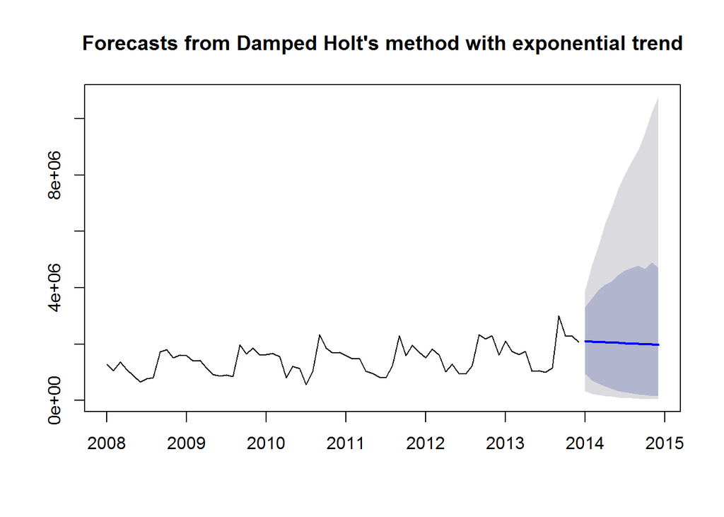

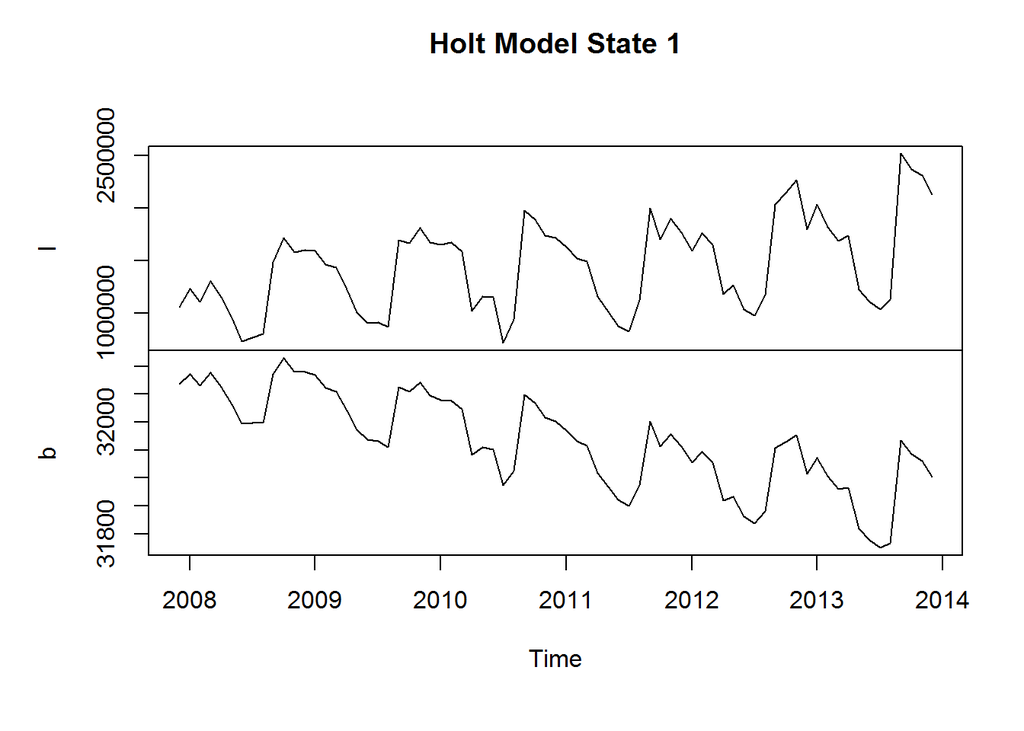

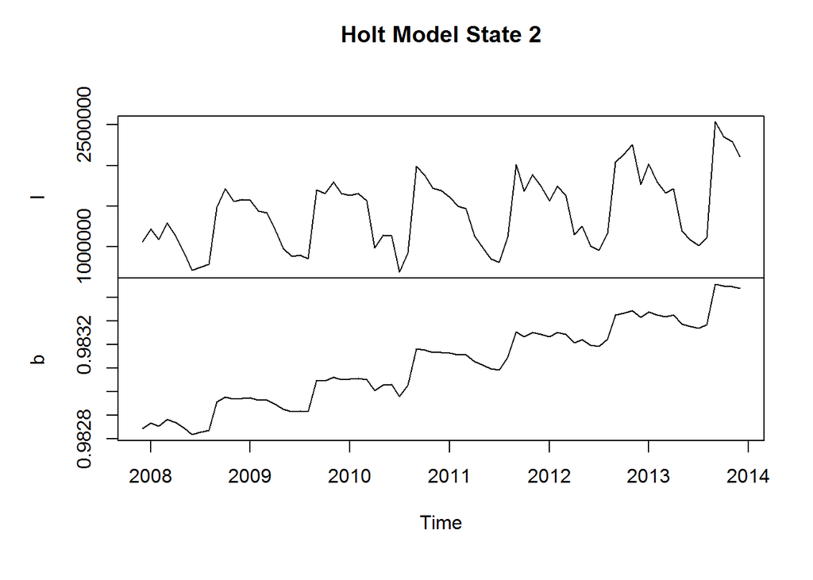

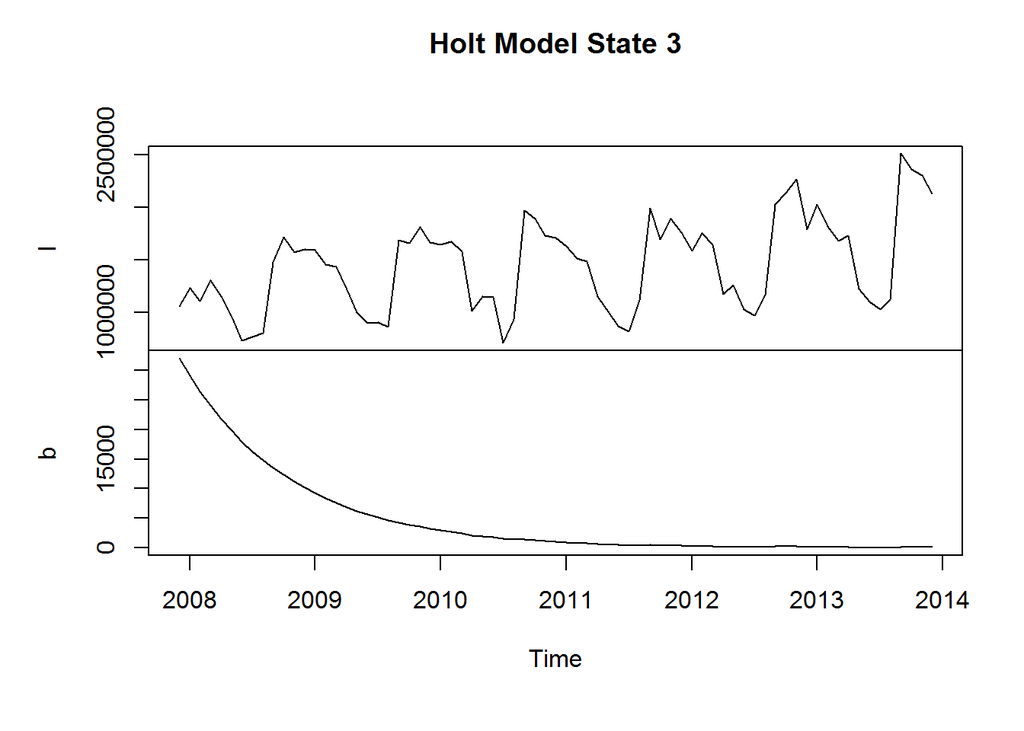

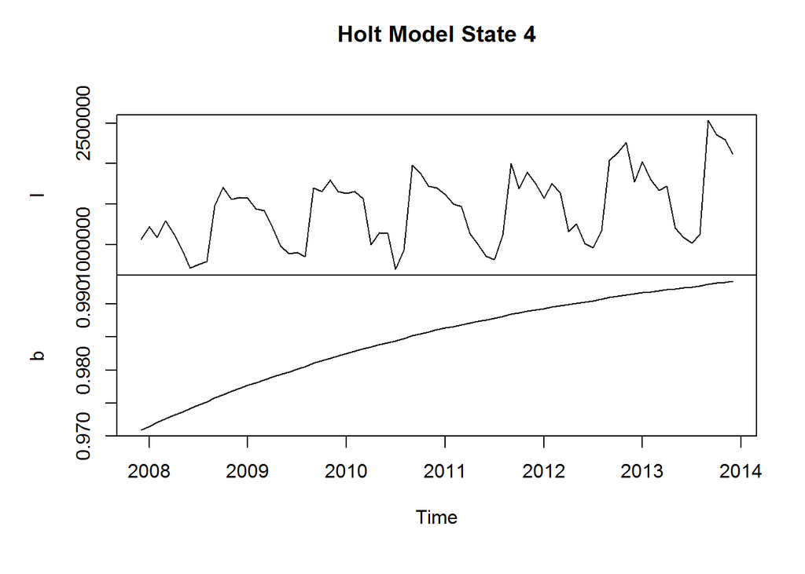

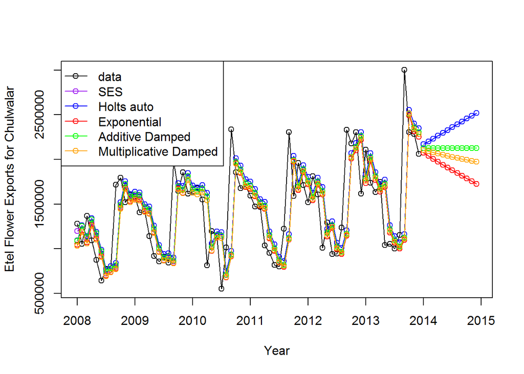

Holt’s auto seems to have the best forecast for the Etel flower exports in 2014.

## 13.3 Holt-Winter’s seasonal method

The AIC is better than the regular Holts Method and the forecast for 201 Etel flower exports follow trends from past years exports.

```
##
## Forecast method: Holt-Winters' additive method
##
## Model Information:
## Holt-Winters' additive method
##
## Call:
##  hw(x = TotalEtelAsIs, h = 12, seasonal = "additive")
##
##   Smoothing parameters:
##     alpha = 0.1006
##     beta  = 4e-04
##     gamma = 1e-04
##
##   Initial states:
##     l = 1197857.198
##     b = 10920.4281
##     s=213227.6 432750.3 389222.1 773339.9 -385004.6 -600027.3
##            -533376.9 -405213.3 -324353.9 76198.07 175183 188055
##
##   sigma:  172689.4
##
##      AIC     AICc      BIC
## 2076.452 2086.343 2112.879
##
## Error measures:
##                  ME     RMSE    MAE       MPE     MAPE      MASE
## Training set -19817 172689.4 137259 -3.310116 10.74612 0.6711232
##                    ACF1
## Training set -0.1543248
##
## Forecasts:
##          Point Forecast   Lo 80   Hi 80     Lo 95   Hi 95
## Jan 2014        2008304 1786994 2229615 1669839.3 2346769
## Feb 2014        2005752 1783307 2228197 1665551.5 2345952
## Mar 2014        1917189 1693606 2140771 1575248.8 2259128
## Apr 2014        1527024 1302302 1751747 1183340.8 1870708
## May 2014        1456525 1230660 1682391 1111093.8 1801957
## Jun 2014        1338726 1111715 1565737  991542.2 1685909
## Jul 2014        1282438 1054279 1510598  933498.5 1631378
## Aug 2014        1507832 1278522 1737143 1157132.1 1858532
## Sep 2014        2676592 2446128 2907057 2324127.9 3029057
## Oct 2014        2302843 2071223 2534464 1948610.2 2657076
## Nov 2014        2356737 2123957 2589516 2000730.8 2712742
## Dec 2014        2147585 1913641 2381529 1789799.1 2505371
```

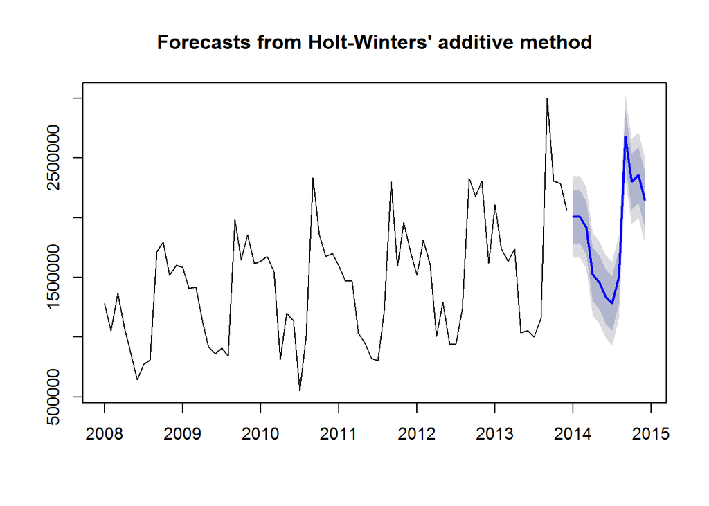

```
##
## Forecast method: Holt-Winters' multiplicative method
##
## Model Information:
## Holt-Winters' multiplicative method
##
## Call:
##  hw(x = TotalEtelAsIs, h = 12, seasonal = "multiplicative")
##
##   Smoothing parameters:
##     alpha = 0.1007
##     beta  = 0.0202
##     gamma = 1e-04
##
##   Initial states:
##     l = 1185233.6784
##     b = 11436.6691
##     s=1.1484 1.3007 1.2775 1.5501 0.7138 0.5675
##            0.6356 0.7225 0.7983 1.0554 1.0793 1.1511
##
##   sigma:  0.1215
##
##      AIC     AICc      BIC
## 2071.694 2081.585 2108.121
##
## Error measures:
##                    ME     RMSE      MAE       MPE     MAPE      MASE
## Training set 2570.544 154506.4 126050.4 -1.274176 9.741218 0.6163191
##                    ACF1
## Training set -0.2582845
##
## Forecasts:
##          Point Forecast     Lo 80   Hi 80     Lo 95   Hi 95
## Jan 2014        2134821 1802370.6 2467272 1626381.7 2643261
## Feb 2014        2018272 1701688.7 2334855 1534099.6 2502444
## Mar 2014        1990076 1674924.2 2305227 1508093.0 2472059
## Apr 2014        1517542 1274319.5 1760765 1145565.3 1889519
## May 2014        1384653 1159472.1 1609834 1040268.6 1729037
## Jun 2014        1228015 1024850.6 1431179  917301.9 1538728
## Jul 2014        1105178  918695.4 1291660  819977.4 1390378
## Aug 2014        1401176 1159448.3 1642903 1031485.6 1770866
## Sep 2014        3067063 2524835.0 3609292 2237796.7 3896330
## Oct 2014        2547465 2084968.1 3009962 1840136.8 3254794
## Nov 2014        2613831 2125584.2 3102077 1867122.3 3360539
## Dec 2014        2325692 1877988.5 2773396 1640988.6 3010396
```

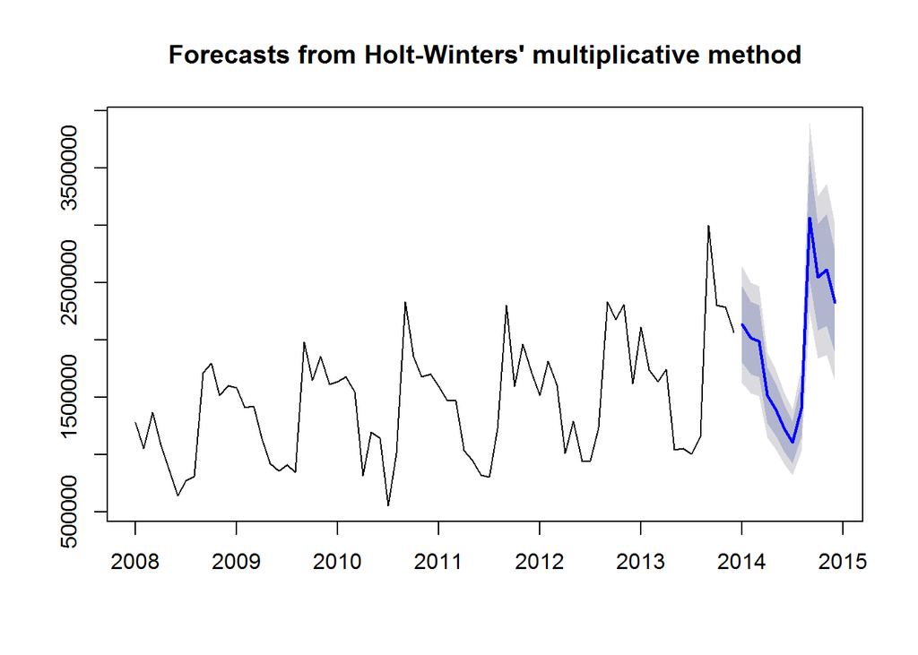

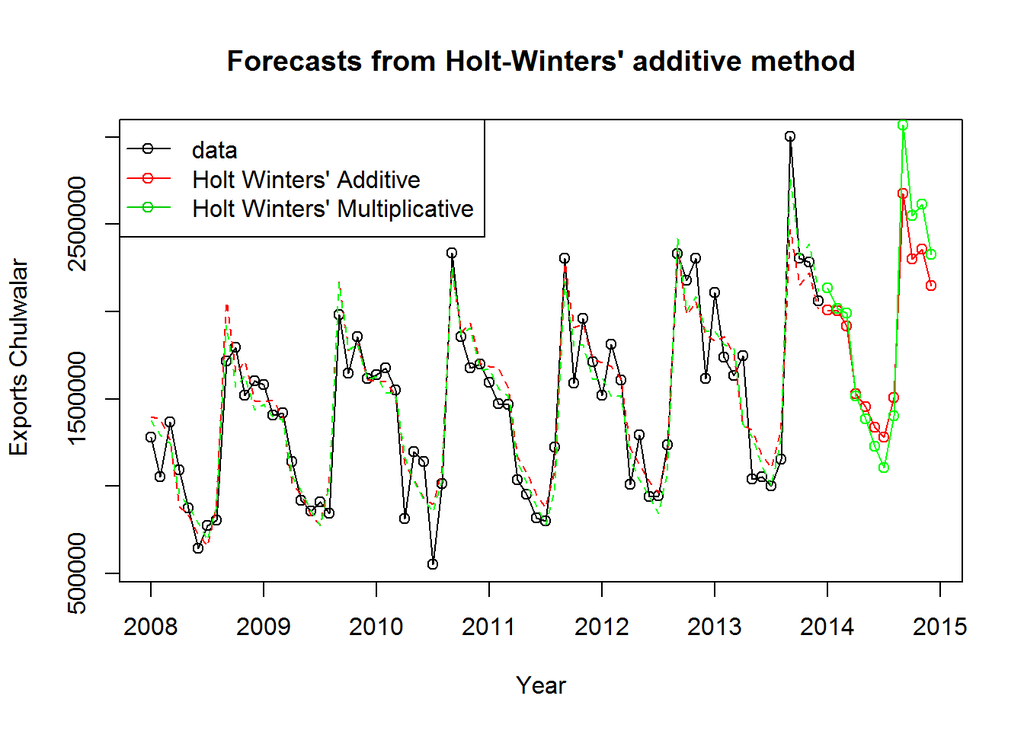

## 13.4 Innovations state space models for exponential smoothing

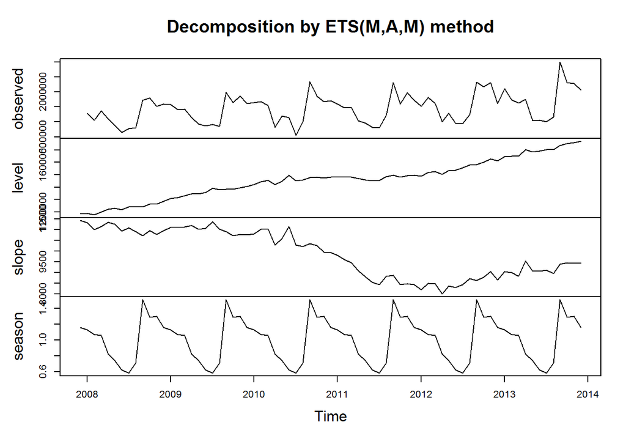

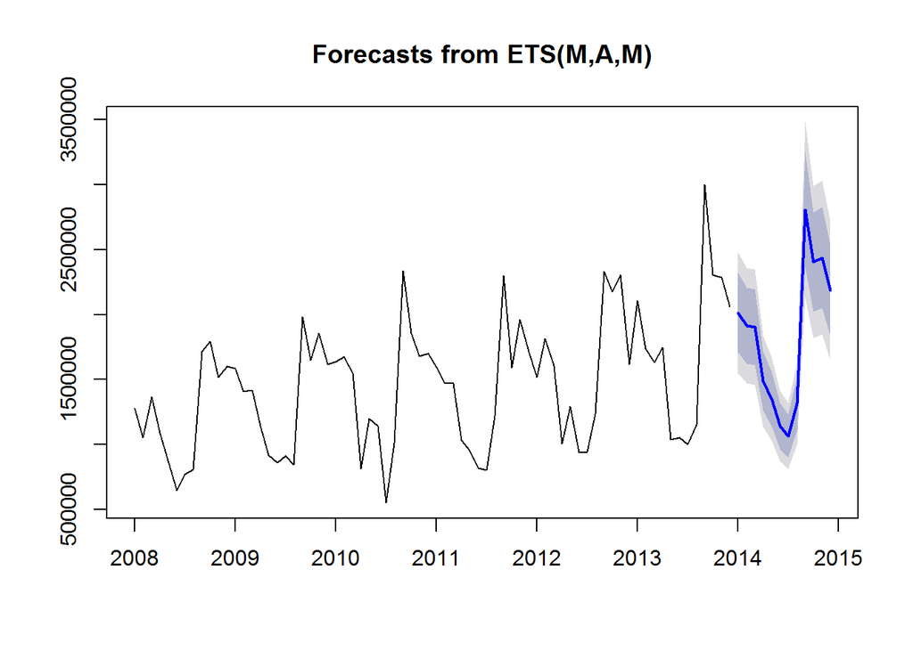

## 13.5 ARIMA Model

The data for the Etel Flower Export is stationary which is supported by the Augmented Dickey-Fuller Test, but there is a warning indicating the p-value is less than 0.01.

```
## Warning in adf.test(TotalEtelAsIs, alternative = "stationary"): p-value
## smaller than printed p-value
```

```
##
##  Augmented Dickey-Fuller Test
##
## data:  TotalEtelAsIs
## Dickey-Fuller = -5.5849, Lag order = 4, p-value = 0.01
## alternative hypothesis: stationary
```

```
##
##  KPSS Test for Level Stationarity
##
## data:  TotalEtelAsIs
## KPSS Level = 0.64854, Truncation lag parameter = 1, p-value =
## 0.01822
```

The data is differenced and retested

```
##
##  Augmented Dickey-Fuller Test
##
## data:  ChulwalarDiff
## Dickey-Fuller = -5.531, Lag order = 4, p-value = 0.01
## alternative hypothesis: stationary
```

```
##
##  KPSS Test for Level Stationarity
##
## data:  ChulwalarDiff
## KPSS Level = 0.021036, Truncation lag parameter = 1, p-value = 0.1
```

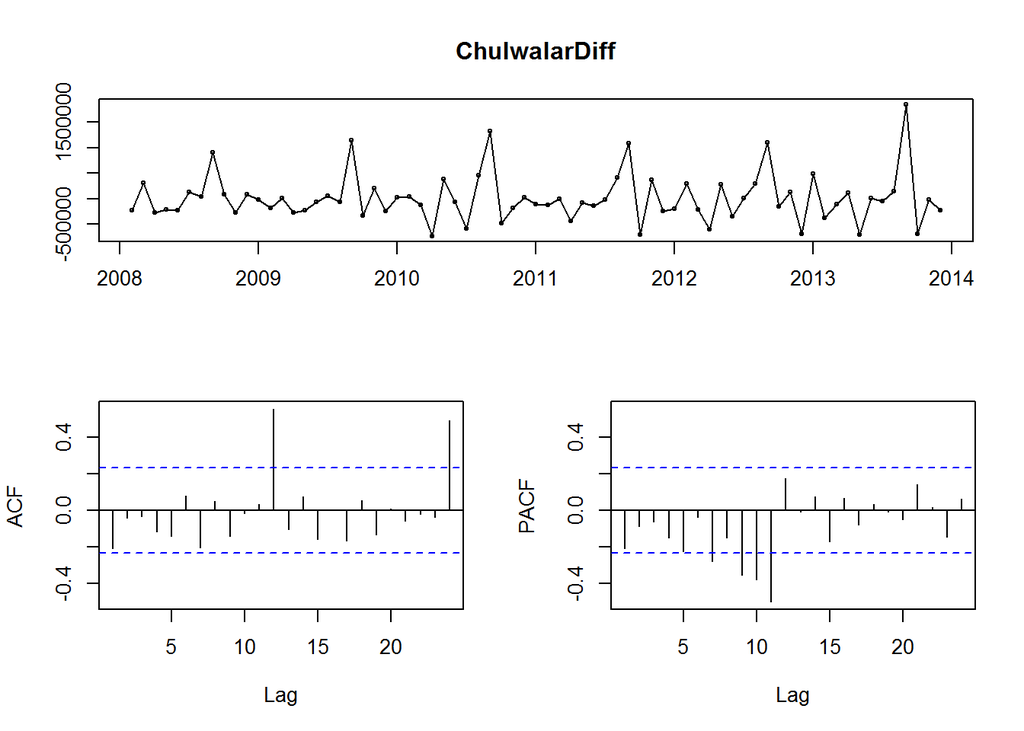

The following test method is used to distinguish the number of “normal” differencing rounds and seasonal differencing rounds. Seasonal differencing is used for data that is dominated by seasonality which Etel Flower exports seem to be. A lag as been added to the time series data for the Etel Flower data.

```
## [1] 0
```

```
## [1] 1
```

```
##          Jan     Feb     Mar     Apr     May     Jun     Jul     Aug
## 2009  303548  354063   53281   50375   46292  214397  137476   36309
## 2010   54248  268773  128759 -327631  278541  281148 -358866  169492
## 2011  -42197 -202633  -79832  221181 -245848 -320721  250808  210270
## 2012  -75519  339369  137552  -26628  339430  120855  143853   12334
## 2013  589749  -74700   26664  737070 -252534  114043   57237  -80471
##          Sep     Oct     Nov     Dec
## 2009  266298 -147817  339548   13767
## 2010  353925  208330 -179713   83972
## 2011  -32217 -264680  282552   14928
## 2012   27063  586311  345649  -95844
## 2013  670595  127710  -21652  444013
```

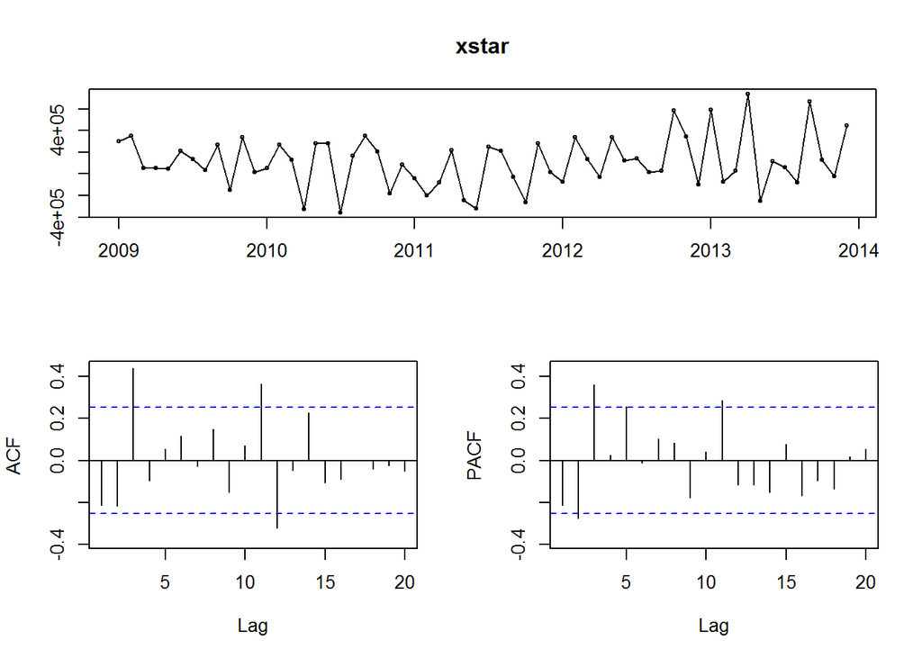

```
##
##  Augmented Dickey-Fuller Test
##
## data:  ChulwalarDiff_lag
## Dickey-Fuller = -3.3973, Lag order = 3, p-value = 0.0648
## alternative hypothesis: stationary
```

```
##
##  KPSS Test for Level Stationarity
##
## data:  ChulwalarDiff_lag
## KPSS Level = 0.26915, Truncation lag parameter = 1, p-value = 0.1
```

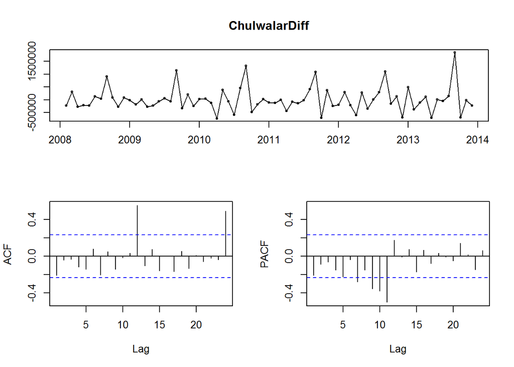

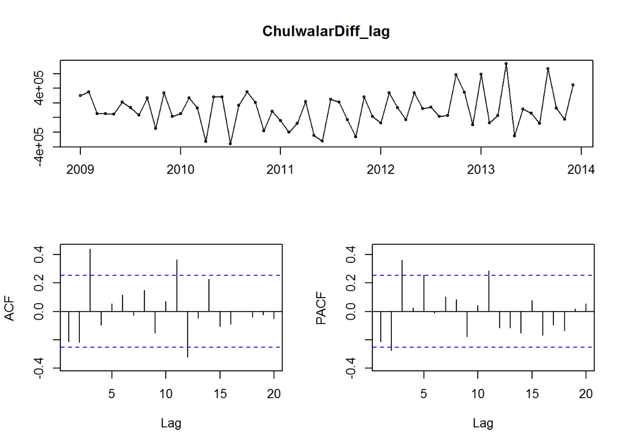

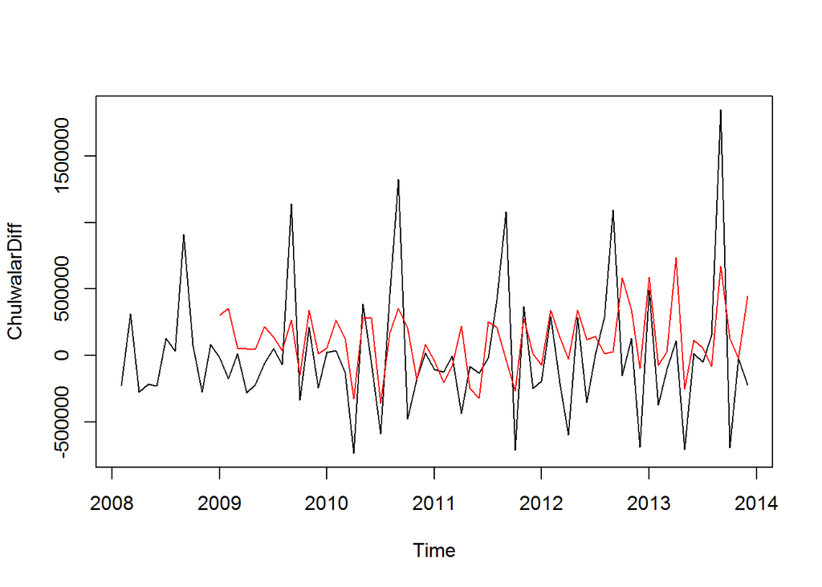

## 13.6 ARIMA modelling

```
## Series: TotalEtelAsIs
## ARIMA(0,1,0)
##
## sigma^2 estimated as 2.24e+11:  log likelihood=-1028.53
## AIC=2059.07   AICc=2059.13   BIC=2061.33
##
## Training set error measures:
##                    ME     RMSE      MAE       MPE     MAPE    MASE
## Training set 10885.72 469992.2 316754.4 -4.183168 22.00733 1.54876
##                    ACF1
## Training set -0.2078636
```

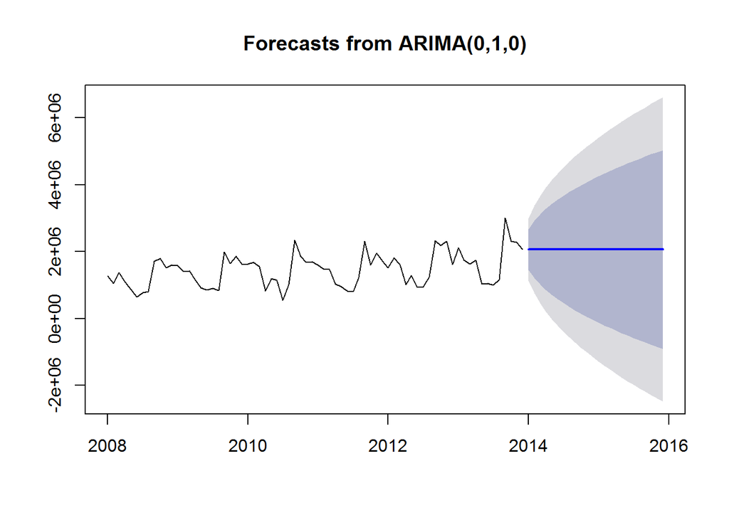

```
## Series: TotalEtelAsIs
## ARIMA(1,1,0)
##
## Coefficients:
##           ar1
##       -0.2054
## s.e.   0.1156
##
## sigma^2 estimated as 2.174e+11:  log likelihood=-1026.99
## AIC=2057.98   AICc=2058.16   BIC=2062.51
##
## Training set error measures:
##                    ME     RMSE      MAE       MPE     MAPE     MASE
## Training set 13820.52 459745.2 299334.9 -4.672899 21.17425 1.463588
##                     ACF1
## Training set -0.02108637
```

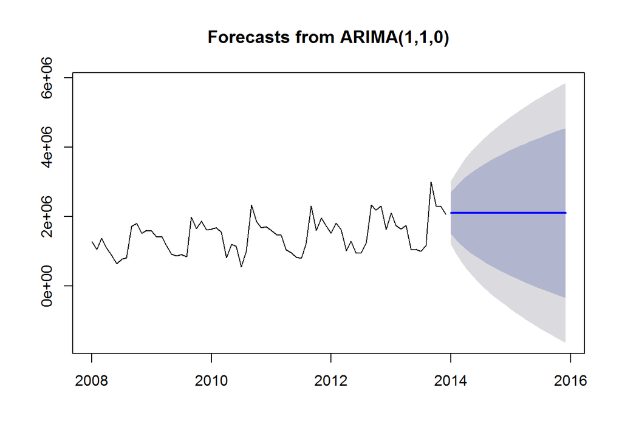

```
## Series: TotalEtelAsIs
## ARIMA(1,1,1)
##
## Coefficients:
##          ar1      ma1
##       0.5356  -0.9577
## s.e.  0.1113   0.0430
##
## sigma^2 estimated as 1.836e+11:  log likelihood=-1021.16
## AIC=2048.32   AICc=2048.68   BIC=2055.11
##
## Training set error measures:
##                    ME   RMSE    MAE       MPE     MAPE     MASE
## Training set 60565.25 419506 278583 -3.430148 20.34803 1.362122
##                      ACF1
## Training set -0.007510009
```

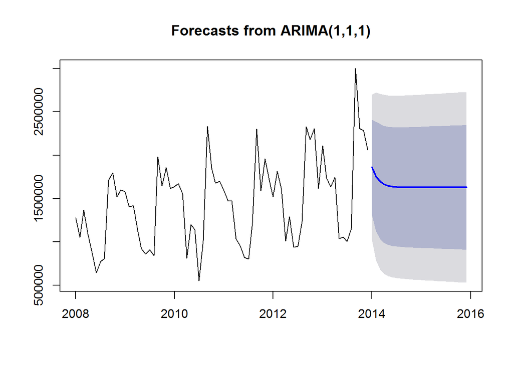

```
## Series: TotalEtelAsIs
## ARIMA(2,1,1)
##
## Coefficients:
##          ar1      ar2      ma1
##       0.5514  -0.0368  -0.9554
## s.e.  0.1228   0.1214   0.0433
##
## sigma^2 estimated as 1.86e+11:  log likelihood=-1021.11
## AIC=2050.23   AICc=2050.84   BIC=2059.28
##
## Training set error measures:
##                    ME     RMSE      MAE       MPE     MAPE     MASE
## Training set 61421.92 419159.8 282807.5 -3.386659 20.62324 1.382777
##                     ACF1
## Training set -0.03269786
```

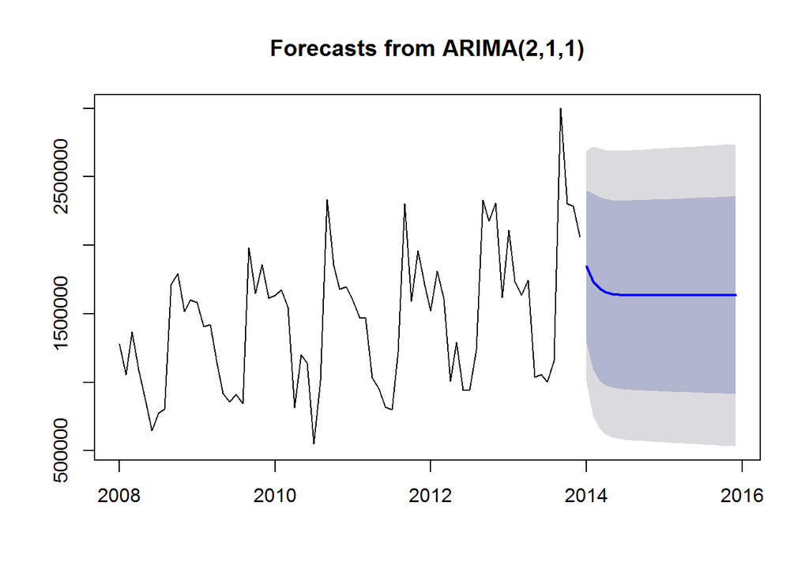

```
## Series: TotalEtelAsIs
## ARIMA(2,1,2)
##
## Coefficients:
##           ar1     ar2     ma1      ma2
##       -0.4041  0.5955  0.0333  -0.9520
## s.e.   0.1098  0.1098  0.0521   0.0512
##
## sigma^2 estimated as 1.724e+11:  log likelihood=-1018.67
## AIC=2047.34   AICc=2048.27   BIC=2058.66
##
## Training set error measures:
##                   ME     RMSE      MAE       MPE     MAPE     MASE
## Training set 55996.3 400535.6 272287.9 -3.192989 20.05191 1.331342
##                    ACF1
## Training set 0.05235937
```

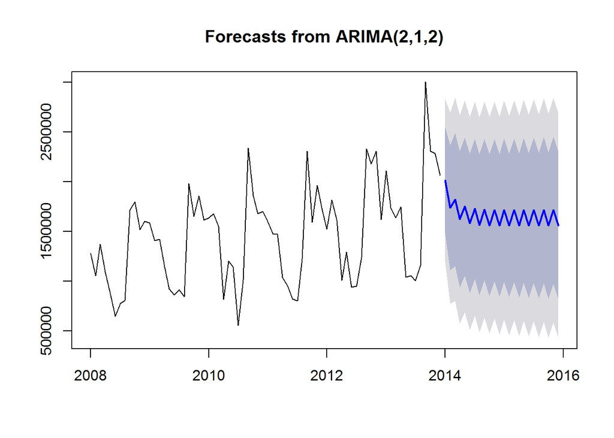

```
## Series: TotalEtelAsIs
## ARIMA(3,1,2)
##
## Coefficients:
##           ar1     ar2      ar3     ma1      ma2
##       -0.3406  0.5094  -0.1498  0.0444  -0.9439
## s.e.   0.1218  0.1221   0.1202  0.0474   0.0470
##
## sigma^2 estimated as 1.701e+11:  log likelihood=-1017.91
## AIC=2047.81   AICc=2049.12   BIC=2061.39
##
## Training set error measures:
##                    ME     RMSE      MAE       MPE     MAPE     MASE
## Training set 60035.76 394839.8 283670.3 -2.931351 20.86698 1.386996
##                     ACF1
## Training set -0.03143675
```

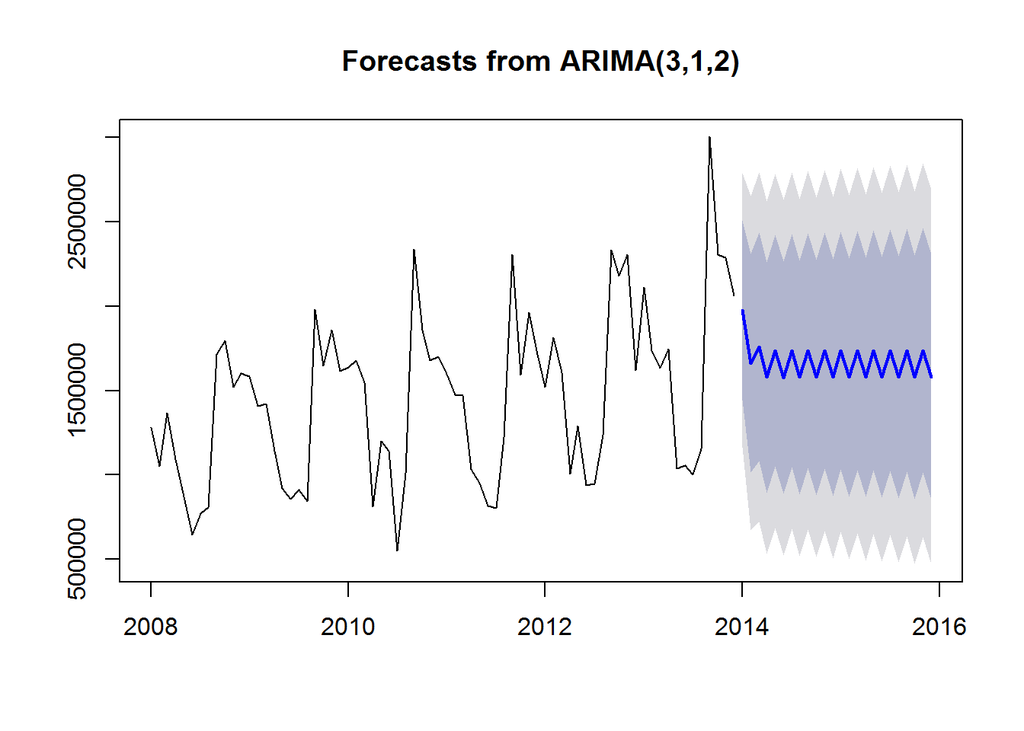

```
## Series: TotalEtelAsIs
## ARIMA(3,1,3)
##
## Coefficients:
##           ar1      ar2     ar3      ma1     ma2      ma3
##       -0.2758  -0.4063  0.5282  -0.1579  0.2256  -0.9625
## s.e.   0.1394   0.1100  0.1275   0.0978  0.1038   0.0853
##
## sigma^2 estimated as 1.738e+11:  log likelihood=-1018.64
## AIC=2051.27   AICc=2053.05   BIC=2067.11
##
## Training set error measures:
##                   ME     RMSE      MAE       MPE     MAPE     MASE
## Training set 56221.9 396058.6 263240.5 -2.968433 18.88281 1.287105
##                    ACF1
## Training set 0.05685117
```

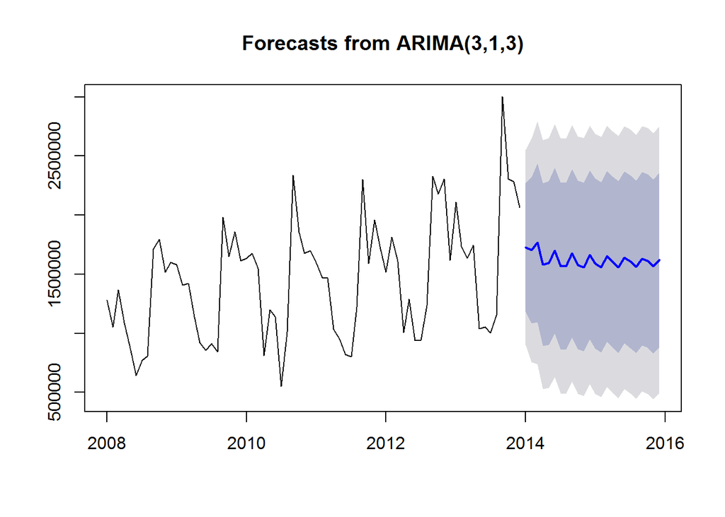

```
## Series: TotalEtelAsIs
## ARIMA(3,1,1)
##
## Coefficients:
##          ar1     ar2      ar3      ma1
##       0.5332  0.0387  -0.1576  -0.9451
## s.e.  0.1207  0.1322   0.1192   0.0431
##
## sigma^2 estimated as 1.839e+11:  log likelihood=-1020.26
## AIC=2050.53   AICc=2051.45   BIC=2061.84
##
## Training set error measures:
##                    ME   RMSE      MAE       MPE     MAPE     MASE
## Training set 65859.38 413668 287169.7 -3.017836 20.98778 1.404106
##                     ACF1
## Training set -0.06767524
```

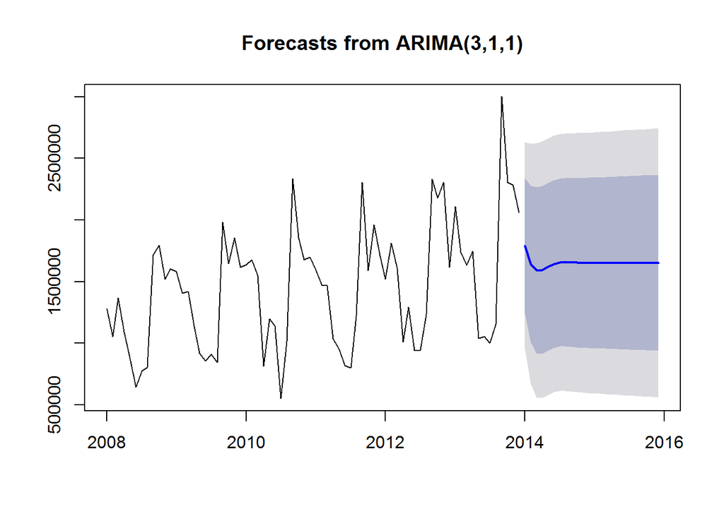

```
## Series: TotalEtelAsIs
## ARIMA(3,1,2)
##
## Coefficients:
##           ar1     ar2      ar3     ma1      ma2
##       -0.3406  0.5094  -0.1498  0.0444  -0.9439
## s.e.   0.1218  0.1221   0.1202  0.0474   0.0470
##
## sigma^2 estimated as 1.701e+11:  log likelihood=-1017.91
## AIC=2047.81   AICc=2049.12   BIC=2061.39
##
## Training set error measures:
##                    ME     RMSE      MAE       MPE     MAPE     MASE
## Training set 60035.76 394839.8 283670.3 -2.931351 20.86698 1.386996
##                     ACF1
## Training set -0.03143675
```

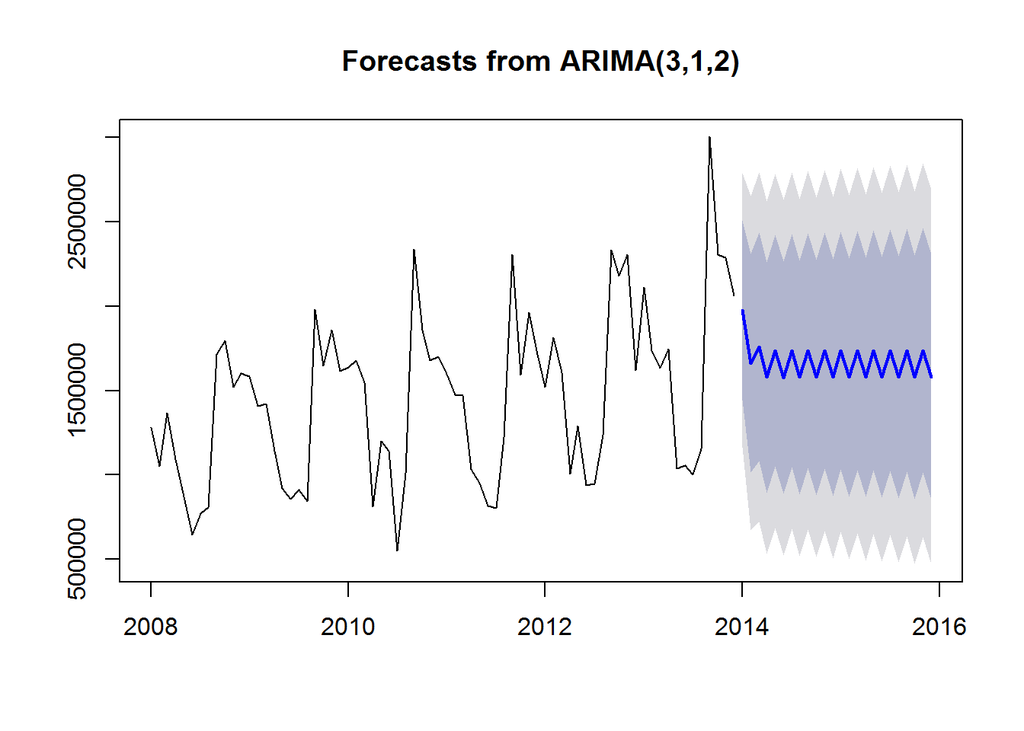

```
## Series: TotalEtelAsIs
## ARIMA(1,1,3)
##
## Coefficients:
##          ar1      ma1     ma2      ma3
##       0.3980  -0.8255  0.0031  -0.1227
## s.e.  0.2521   0.2524  0.2183   0.1489
##
## sigma^2 estimated as 1.872e+11:  log likelihood=-1020.82
## AIC=2051.64   AICc=2052.56   BIC=2062.95
##
## Training set error measures:
##                    ME     RMSE      MAE       MPE     MAPE     MASE
## Training set 61338.98 417381.6 279203.2 -3.304679 20.40418 1.365154
##                     ACF1
## Training set -0.01613915
```

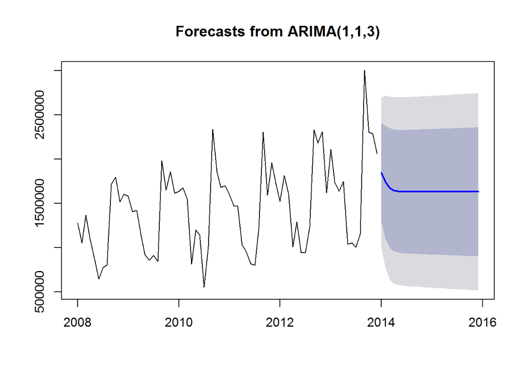

```
## Series: TotalEtelAsIs
## ARIMA(2,1,3)
##
## Coefficients:
##           ar1      ar2     ma1      ma2      ma3
##       -1.1884  -0.1895  1.0274  -0.8487  -0.8956
## s.e.   0.1536   0.1535  0.2043   0.0964   0.1831
##
## sigma^2 estimated as 1.56e+11:  log likelihood=-1016.68
## AIC=2045.36   AICc=2046.67   BIC=2058.94
##
## Training set error measures:
##                    ME     RMSE      MAE       MPE     MAPE     MASE
## Training set 59423.55 378168.1 294500.1 -2.845444 21.91275 1.439948
##                    ACF1
## Training set 0.01497287
```

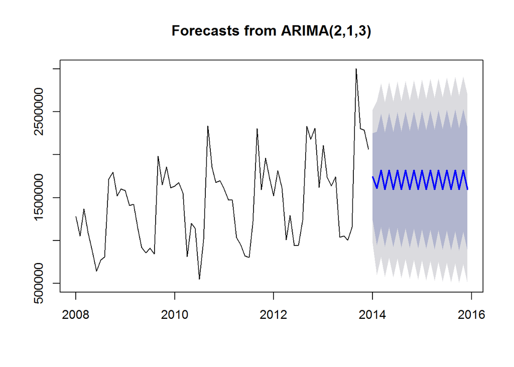

```
## Series: TotalEtelAsIs
## ARIMA(2,2,3)
##
## Coefficients:
##           ar1     ar2      ma1      ma2     ma3
##       -0.4189  0.5809  -1.0014  -0.9851  0.9946
## s.e.   0.1062  0.1062   0.0664   0.0503  0.0661
##
## sigma^2 estimated as 1.685e+11:  log likelihood=-1007.22
## AIC=2026.44   AICc=2027.78   BIC=2039.93
##
## Training set error measures:
##                    ME     RMSE      MAE       MPE     MAPE    MASE
## Training set 13591.95 389968.3 271275.1 -5.646689 20.46811 1.32639
##                    ACF1
## Training set 0.07307373
```

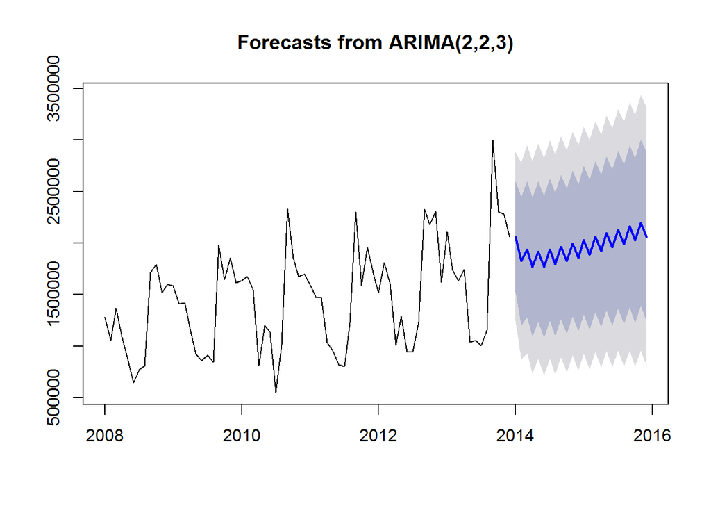

```
## Series: TotalEtelAsIs
## ARIMA(2,3,2)
##
## Coefficients:
##           ar1      ar2      ma1     ma2
##       -0.1902  -0.0549  -1.9947  1.0000
## s.e.   0.1217   0.1208   0.0558  0.0555
##
## sigma^2 estimated as 2.356e+11:  log likelihood=-1005.86
## AIC=2021.72   AICc=2022.67   BIC=2032.89
##
## Training set error measures:
##                     ME     RMSE      MAE       MPE     MAPE     MASE
## Training set -9029.484 461153.8 309811.9 -4.878339 21.42473 1.514814
##                     ACF1
## Training set -0.01924413
```

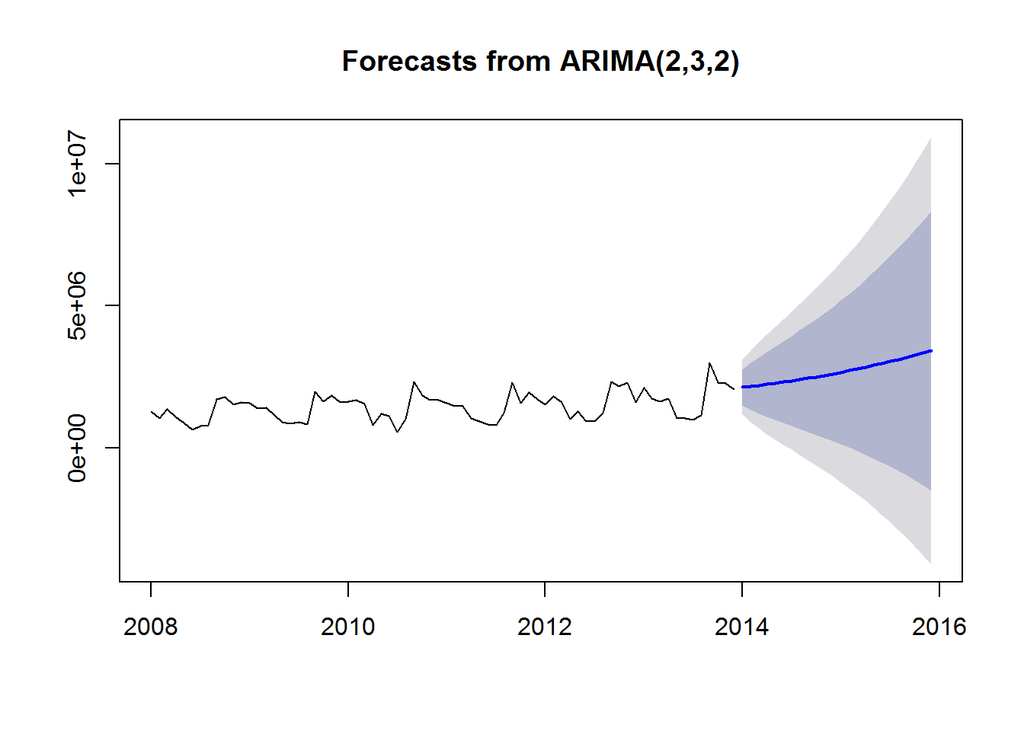

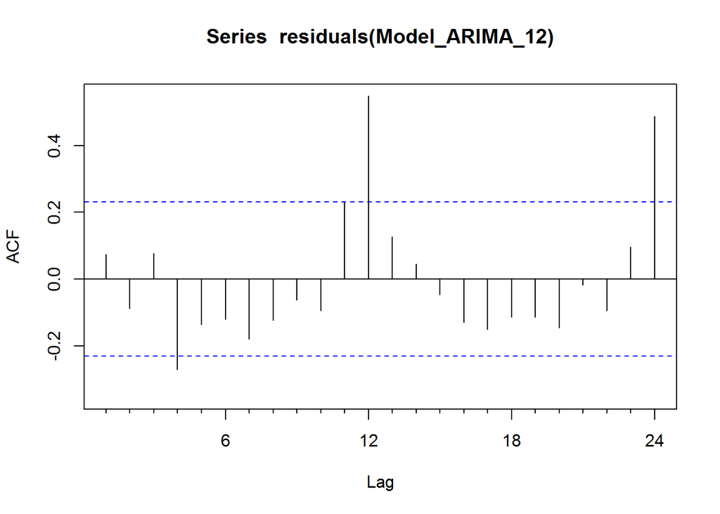

```
##
##  Box-Ljung test
##
## data:  residuals(Model_ARIMA_12)
## X-squared = 46.18, df = 8, p-value = 2.197e-07
```

## 13.7 Seasonal ARIMA modelling

The more the seasonal aspect is changed, the better the results based on AIC, AICc and BIC. Theoretically the models should more and more suitable for the forecast. However, a look at the plot of the forecasts shows that the changes are making the data less and less convincing and thus unuseable.

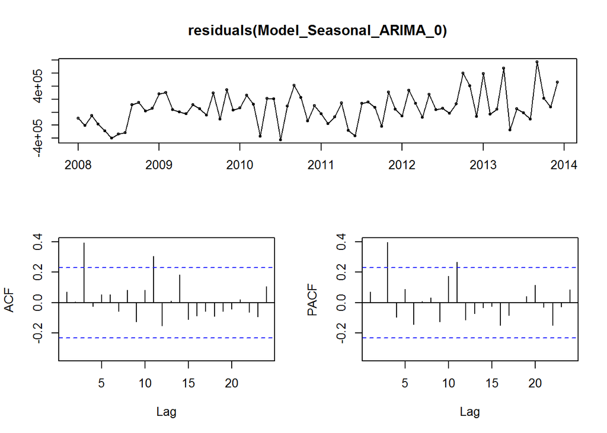

```
## Series: TotalEtelAsIs
## ARIMA(0,0,0)(1,0,0)[12] with non-zero mean
##
## Coefficients:
##         sar1  intercept
##       0.8791  1476037.4
## s.e.  0.0444   135244.5
##
## sigma^2 estimated as 6.777e+10:  log likelihood=-1007.86
## AIC=2021.72   AICc=2022.07   BIC=2028.55
##
## Training set error measures:
##                    ME     RMSE      MAE        MPE     MAPE    MASE
## Training set 62343.65 256689.5 194587.8 0.05466362 14.82089 0.95143
##                    ACF1
## Training set 0.07066295
```

```
## Series: TotalEtelAsIs
## ARIMA(0,1,1)(0,1,1)[12]
##
## Coefficients:
##           ma1     sma1
##       -0.9102  -0.6446
## s.e.   0.0678   0.2063
##
## sigma^2 estimated as 4.546e+10:  log likelihood=-810.93
## AIC=1627.85   AICc=1628.29   BIC=1634.08
##
## Training set error measures:
##                     ME     RMSE      MAE       MPE     MAPE      MASE
## Training set -3607.306 189704.1 135489.8 -2.864112 10.12317 0.6624726
##                    ACF1
## Training set -0.1808033
```

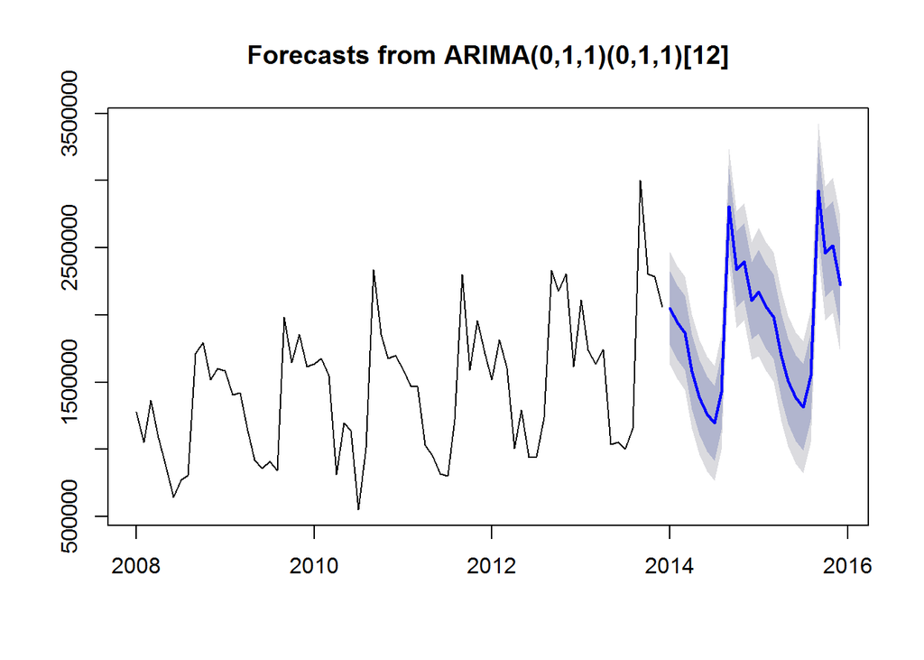

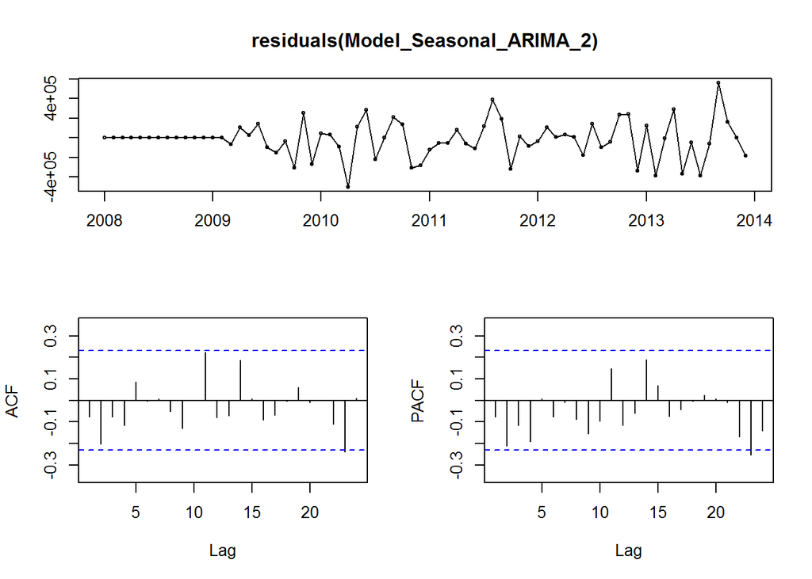

```
## Series: TotalEtelAsIs
## ARIMA(2,3,2)(1,1,1)[12]
##
## Coefficients:
##           ar1      ar2      ma1     ma2     sar1     sma1
##       -0.8074  -0.6593  -1.9804  0.9974  -0.3563  -0.1610
## s.e.   0.0982   0.1000   0.0734  0.0725   0.2816   0.3205
##
## sigma^2 estimated as 4.929e+10:  log likelihood=-789.61
## AIC=1593.23   AICc=1595.51   BIC=1607.53
##
## Training set error measures:
##                     ME     RMSE      MAE       MPE     MAPE      MASE
## Training set -17124.16 186845.5 129418.7 -2.576346 9.671933 0.6327881
##                     ACF1
## Training set -0.07718252
```

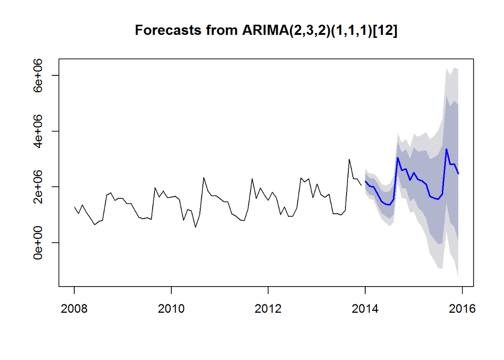

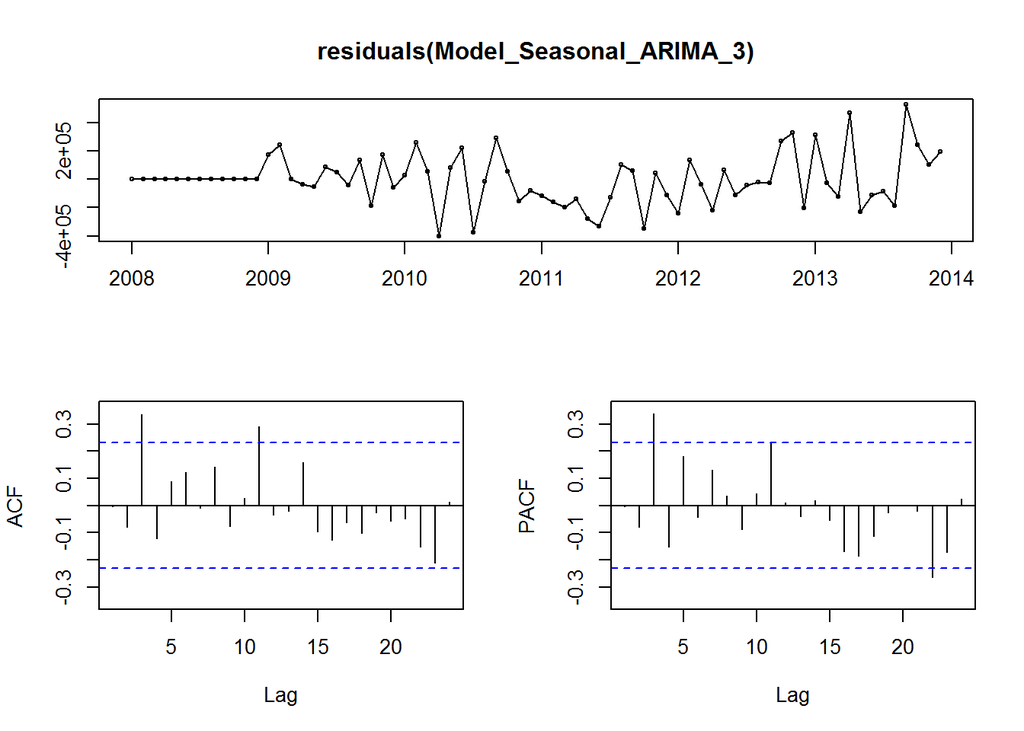

```
## Series: TotalEtelAsIs
## ARIMA(1,0,1)(1,1,1)[12] with drift
##
## Coefficients:
##          ar1      ma1    sar1     sma1     drift
##       0.0529  -0.2166  0.1426  -0.7595  8211.122
## s.e.  0.3959   0.3731  0.3241   0.4232  1057.928
##
## sigma^2 estimated as 4.355e+10:  log likelihood=-821.18
## AIC=1654.36   AICc=1655.94   BIC=1666.92
##
## Training set error measures:
##                     ME     RMSE      MAE       MPE     MAPE      MASE
## Training set -1960.418 182403.2 133660.4 -2.755316 9.997192 0.6535278
##                      ACF1
## Training set -0.003556865
```

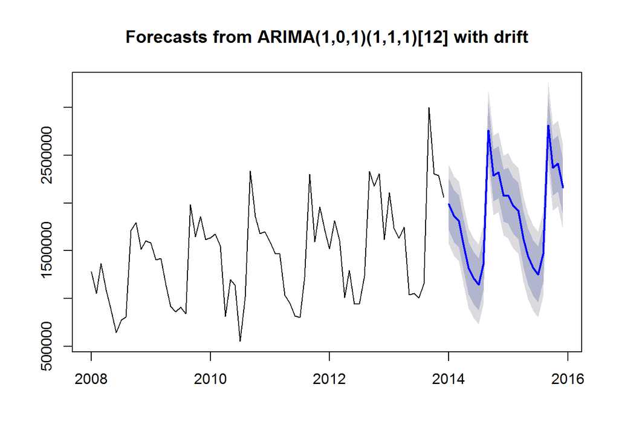

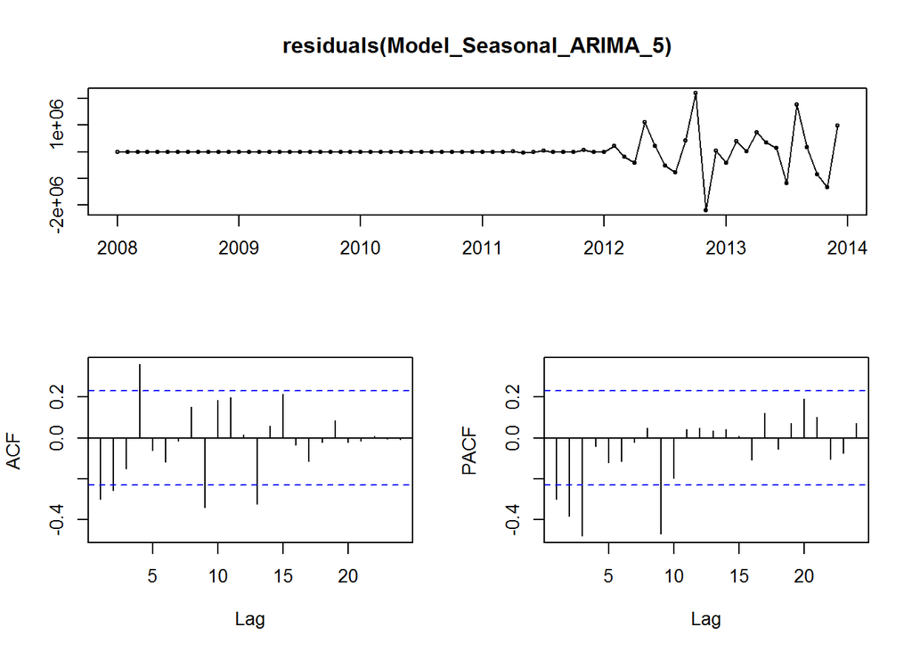

```
## Series: TotalEtelAsIs
## ARIMA(2,3,2)(1,4,2)[12]
##
## Coefficients:
```

```
##           ar1      ar2      ma1     ma2    sar1     sma1    sma2
##       -0.9573  -0.9985  -1.1358  0.1358  -0.731  -0.5097  0.0399
## s.e.   0.0638   0.0016   0.4299  0.4713     NaN      NaN     NaN
##
## sigma^2 estimated as 1.526e+12:  log likelihood=-353.25
## AIC=722.5   AICc=734.5   BIC=730.86
##
## Training set error measures:
##                    ME     RMSE      MAE       MPE     MAPE     MASE
## Training set 13377.73 544801.2 234374.8 0.9640717 15.00136 1.145967
##                    ACF1
## Training set -0.3006175
```

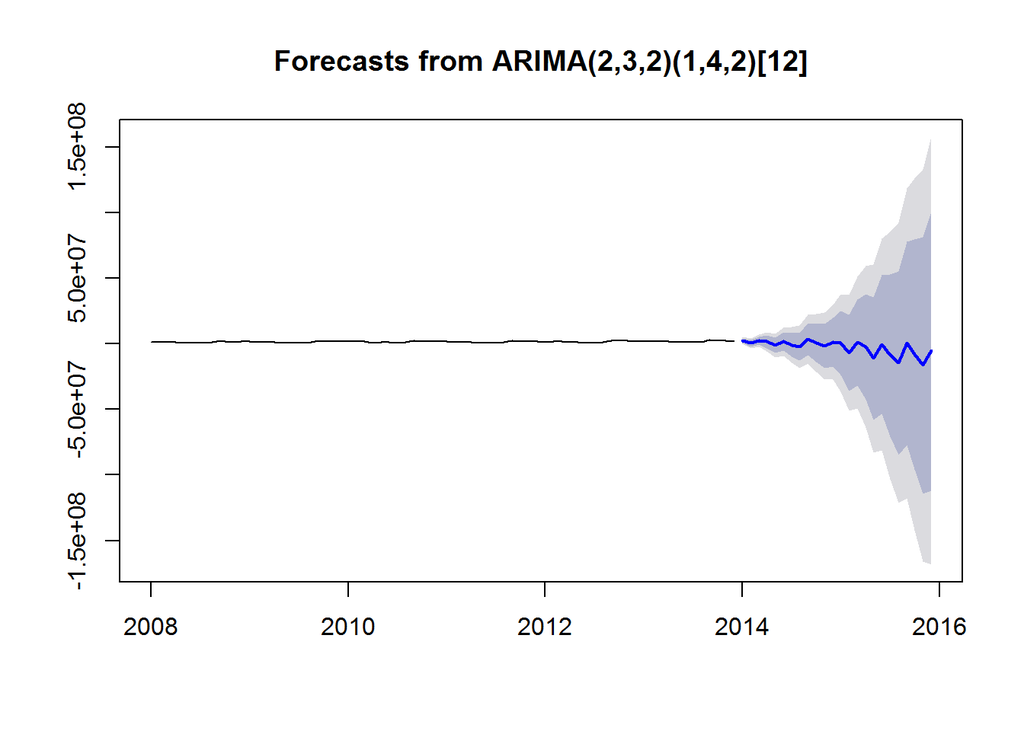

## 13.8 Auto-ARIMA modelling

```
## Series: TotalEtelAsIs
## ARIMA(3,0,2)(1,1,0)[12] with drift
##
## Coefficients:
##          ar1     ar2     ar3      ma1      ma2     sar1     drift
##       0.0371  0.2713  0.5030  -0.0998  -0.4695  -0.4017  9852.810
## s.e.  0.1780  0.1780  0.1157   0.2018   0.1828   0.1379  3240.753
##
## sigma^2 estimated as 3.911e+10:  log likelihood=-814.54
## AIC=1645.08   AICc=1647.91   BIC=1661.84
##
## Training set error measures:
##                     ME     RMSE      MAE       MPE     MAPE      MASE
## Training set -1264.393 169669.5 128332.6 -2.233268 9.440145 0.6274777
##                      ACF1
## Training set -0.001515626
```

```
##           CV          AIC         AICc          BIC        AdjR2
## 4.081446e+10 1.757920e+03 1.765288e+03 1.789793e+03 8.682746e-01
```

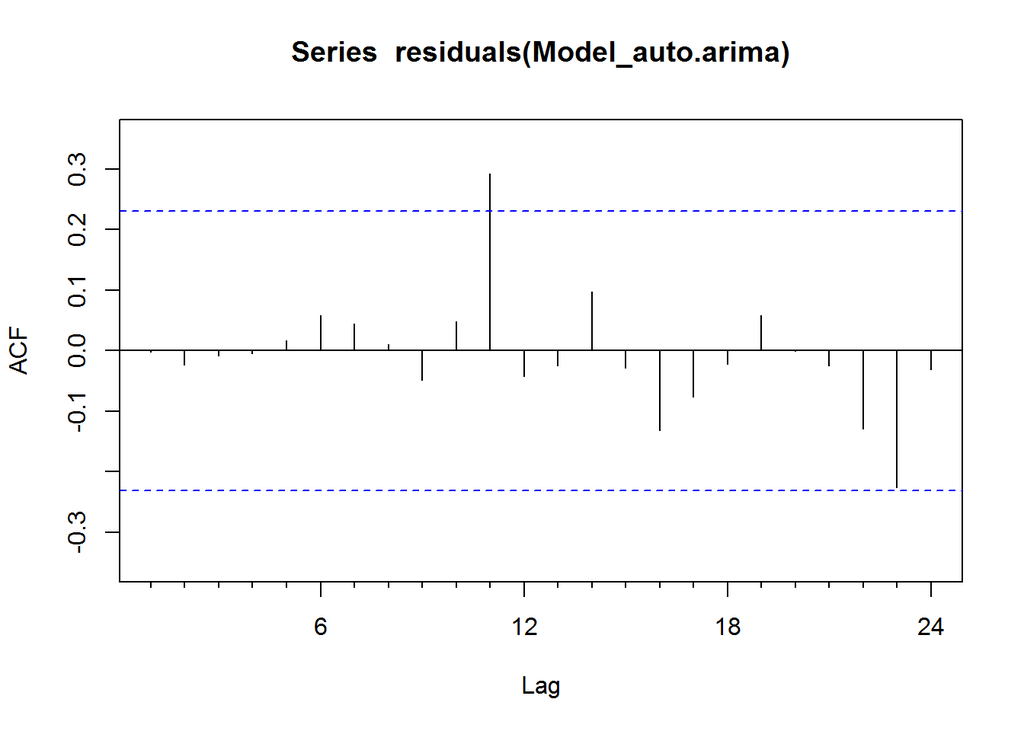

```
##
##  Box-Ljung test
##
## data:  residuals(Model_auto.arima)
## X-squared = 8.5341, df = 8, p-value = 0.3831
```

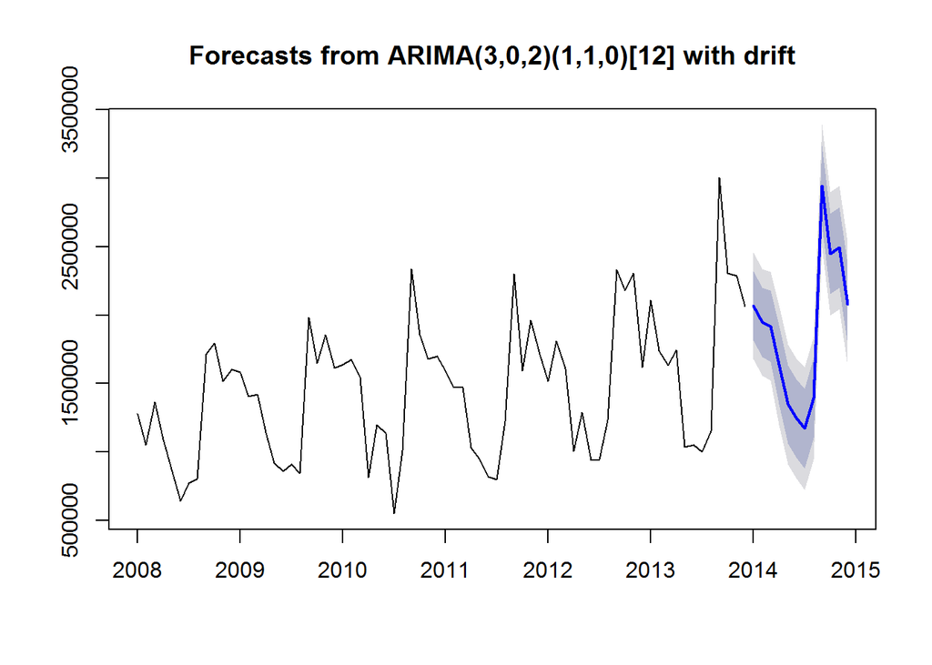

```
##          Point Forecast     Lo 80   Hi 80     Lo 95   Hi 95
## Jan 2014        2068608 1815172.2 2322044 1681011.3 2456205
## Feb 2014        1948186 1694252.2 2202120 1559827.8 2336544
## Mar 2014        1918326 1659356.5 2177295 1522266.5 2314385
## Apr 2014        1638644 1352676.7 1924611 1201294.9 2075992
## May 2014        1349768 1063278.7 1636256  911620.6 1787914
## Jun 2014        1247277  960709.7 1533844  809010.2 1685544
## Jul 2014        1172341  880242.3 1464439  725614.7 1619067
## Aug 2014        1395261 1103123.0 1687398  948474.8 1842046
## Sep 2014        2942839 2650114.0 3235565 2495154.6 3390524
## Oct 2014        2446561 2152513.4 2740608 1996854.2 2896267
## Nov 2014        2493834 2199763.9 2787904 2044092.7 2943575
## Dec 2014        2080932 1786370.3 2375494 1630438.6 2531426
```

```
##          Jan     Feb     Mar     Apr     May     Jun     Jul     Aug
## 2014 2068608 1948186 1918326 1638644 1349768 1247277 1172341 1395261
##          Sep     Oct     Nov     Dec
## 2014 2942839 2446561 2493834 2080932
```

## 13.9 Dynamic regression models

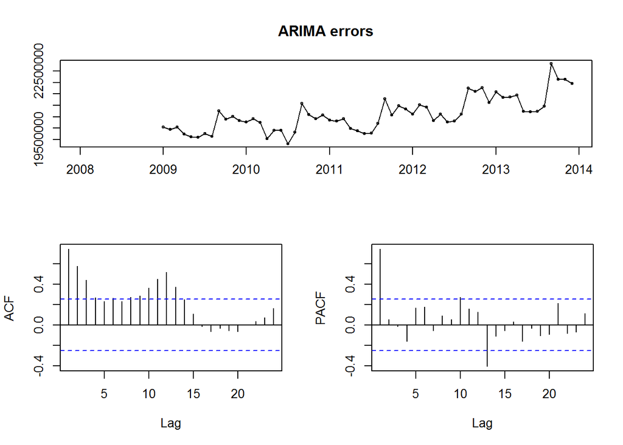

```
## Series: TotalEtelAsIs
## ARIMA(2,2,0)
##
## Coefficients:
##           ar1      ar2  CEPI_lagged
##       -0.7910  -0.4090    -189524.6
## s.e.   0.1183   0.1198     212476.4
##
## sigma^2 estimated as 2.959e+11:  log likelihood=-856.23
## AIC=1720.46   AICc=1721.08   BIC=1729.46
##
## Training set error measures:
##                     ME   RMSE    MAE       MPE     MAPE     MASE
## Training set -5548.795 574848 416947 -2.292006 27.37392 2.038648
##                     ACF1
## Training set -0.08476448
```

```
## Series: TotalEtelAsIs
## ARIMA(2,1,0)(1,1,0)[12]
##
## Coefficients:
##           ar1      ar2     sar1  CEPI_lagged
##       -0.8380  -0.6707  -0.5724     67894.04
## s.e.   0.1043   0.1070   0.1332     76622.88
##
## sigma^2 estimated as 3.476e+10:  log likelihood=-643.79
## AIC=1297.58   AICc=1298.71   BIC=1307.97
##
## Training set error measures:
##                    ME     RMSE      MAE       MPE     MAPE      MASE
## Training set 2464.261 178508.3 127632.1 -1.259806 9.067804 0.6240525
##                     ACF1
## Training set -0.02199872
```

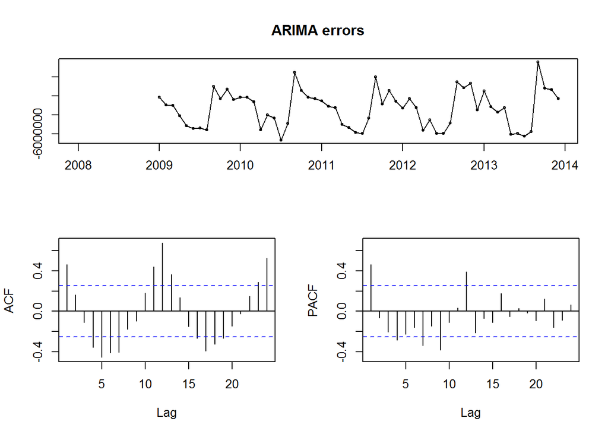

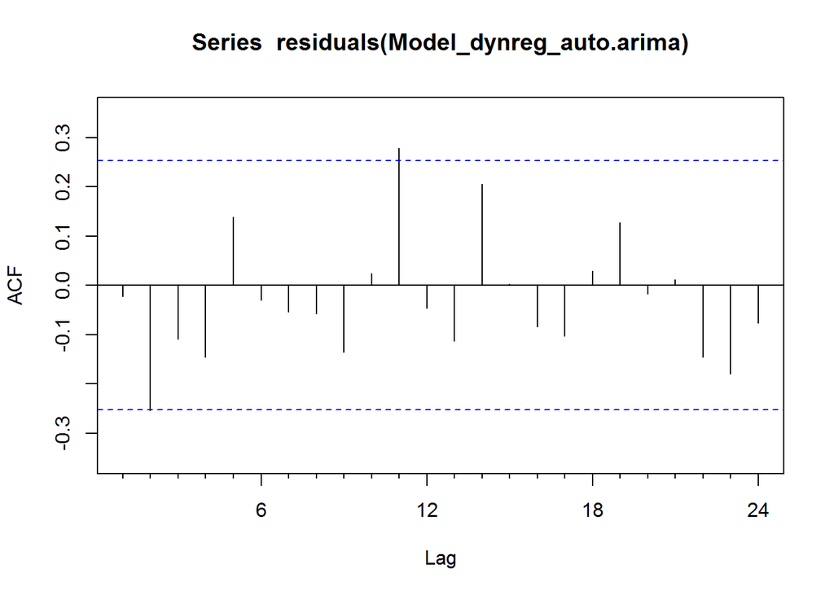

```
##
##  Box-Ljung test
##
## data:  residuals(Model_dynreg_auto.arima)
## X-squared = 15.574, df = 8, p-value = 0.0489
```

```
## Series: TotalEtelAsIs
## ARIMA(2,1,0)(1,1,0)[12]
##
## Coefficients:
##           ar1      ar2     sar1  CEPI_lagged
##       -0.8380  -0.6707  -0.5724     67894.04
## s.e.   0.1043   0.1070   0.1332     76622.88
##
## sigma^2 estimated as 3.476e+10:  log likelihood=-643.79
## AIC=1297.58   AICc=1298.71   BIC=1307.97
##
## Training set error measures:
##                    ME     RMSE      MAE       MPE     MAPE      MASE
## Training set 2464.261 178508.3 127632.1 -1.259806 9.067804 0.6240525
##                     ACF1
## Training set -0.02199872
```

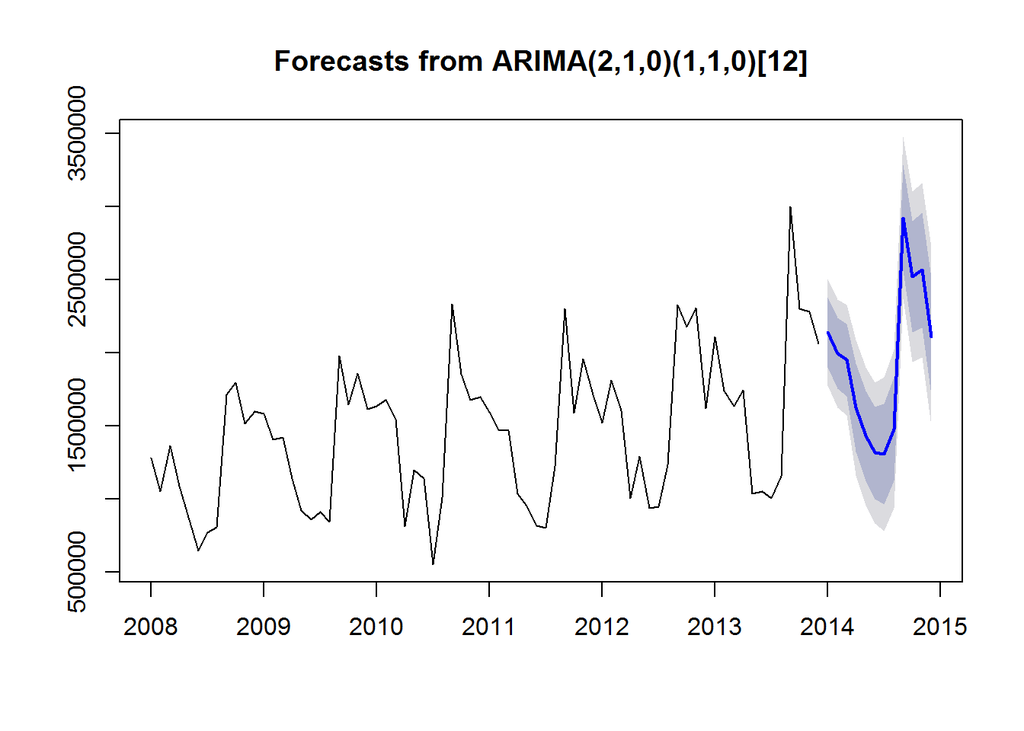

```
##          Point Forecast     Lo 80   Hi 80     Lo 95   Hi 95
## Jan 2014        2142641 1903700.8 2381581 1777213.6 2508068
## Feb 2014        1996013 1753958.4 2238068 1625822.3 2366204
## Mar 2014        1951716 1705284.7 2198148 1574831.7 2328601
## Apr 2014        1625985 1324182.5 1927787 1164417.9 2087552
## May 2014        1432031 1123941.4 1740120  960848.9 1903212
## Jun 2014        1315721  999737.7 1631703  832466.4 1798975
## Jul 2014        1308007  962967.4 1653047  780314.4 1835700
## Aug 2014        1478998 1125747.1 1832250  938747.2 2019250
## Sep 2014        2923917 2561154.2 3286680 2369119.0 3478715
## Oct 2014        2522277 2140496.5 2904057 1938394.2 3106159
## Nov 2014        2566337 2175452.6 2957221 1968531.0 3164143
## Dec 2014        2109905 1709051.5 2510759 1496852.4 2722958
```

```
##          Jan     Feb     Mar     Apr     May     Jun     Jul     Aug
## 2014 2142641 1996013 1951716 1625985 1432031 1315721 1308007 1478998
##          Sep     Oct     Nov     Dec
## 2014 2923917 2522277 2566337 2109905
```

# 14 New Model

As trend and seasonality have been shown to forecast well on their own, we will add the new combination to trend and seasonality in order to try to improve the forecast. Inflation and NationalHolidays additional Seasonality and Trend only.

```
##
## Call:
## tslm(formula = TotalEtelAsIs ~ trend + season + Inflation + NationalHolidays)
##
## Residuals:
##     Min      1Q  Median      3Q     Max
## -326416 -114404    3978  112658  473492
##
## Coefficients:
##                  Estimate Std. Error t value Pr(>|t|)
## (Intercept)       1427775      88398  16.152  < 2e-16 ***
## trend                8104       1015   7.987 7.22e-11 ***
## season2           -101062     101852  -0.992   0.3253
## season3            -57716     108042  -0.534   0.5953
## season4           -372675     124961  -2.982   0.0042 **
## season5           -608371     101929  -5.969 1.62e-07 ***
## season6           -752352     101972  -7.378 7.46e-10 ***
## season7           -839325     102029  -8.226 2.90e-11 ***
## season8           -631888     102092  -6.189 7.03e-08 ***
## season9            590700     102175   5.781 3.27e-07 ***
## season10           198226     102296   1.938   0.0576 .
## season11           226670     102441   2.213   0.0309 *
## season12           206842     149352   1.385   0.1715
## Inflation          -35130      24890  -1.411   0.1636
## NationalHolidays  -205764     108214  -1.901   0.0623 .
## ---
## Signif. codes:  0 '***' 0.001 '**' 0.01 '*' 0.05 '.' 0.1 ' ' 1
##
## Residual standard error: 176400 on 57 degrees of freedom
## Multiple R-squared:  0.9009, Adjusted R-squared:  0.8765
## F-statistic:    37 on 14 and 57 DF,  p-value: < 2.2e-16
```

```
##
## Call:
## tslm(formula = TotalEtelAsIs ~ trend + season)
##
## Residuals:
##     Min      1Q  Median      3Q     Max
## -352676 -105634    5934  107814  481013
##
## Coefficients:
##             Estimate Std. Error t value Pr(>|t|)
## (Intercept)  1370632      81168  16.886  < 2e-16 ***
## trend           8070       1048   7.702 1.75e-10 ***
## season2      -101964     105202  -0.969   0.3364
## season3      -128812     105218  -1.224   0.2257
## season4      -506178     105244  -4.810 1.08e-05 ***
## season5      -607122     105281  -5.767 3.14e-07 ***
## season6      -751654     105327  -7.136 1.59e-09 ***
## season7      -838360     105385  -7.955 6.51e-11 ***
## season8      -631474     105452  -5.988 1.35e-07 ***
## season9       592436     105531   5.614 5.60e-07 ***
## season10      202397     105619   1.916   0.0602 .
## season11      232807     105718   2.202   0.0316 *
## season12        8713     105827   0.082   0.9347
## ---
## Signif. codes:  0 '***' 0.001 '**' 0.01 '*' 0.05 '.' 0.1 ' ' 1
##
## Residual standard error: 182200 on 59 degrees of freedom
## Multiple R-squared:  0.8905, Adjusted R-squared:  0.8683
## F-statistic:    40 on 12 and 59 DF,  p-value: < 2.2e-16
```

The adjusted R square for the Inflation and National Holiday model is 0.8765 whereas the adjusted R Square for the Seasonality and Trend model is 0.8683. The Inflation and National Holiday model seems to work a little better but inflation is not statistically signifcant with a p-value of 0.1636.

## 14.1 Forecasting with the New Model

There is a very strong correlation between the new model and the forcast plan using the Inflation and National Holiday indicators.

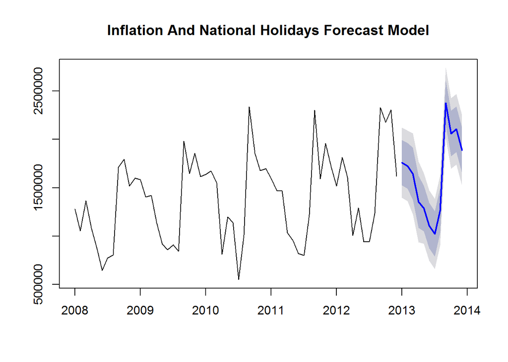

```
##          Point Forecast     Lo 80   Hi 80     Lo 95   Hi 95
## Jan 2013        1760202 1525178.1 1995226 1396258.6 2124146
## Feb 2013        1726107 1490947.7 1961266 1361954.2 2090260
## Mar 2013        1643963 1373595.2 1914332 1225288.3 2062639
## Apr 2013        1354102 1084589.1 1623615  936751.3 1771453
## May 2013        1287073 1051975.2 1522170  923015.5 1651130
## Jun 2013        1111051  876065.7 1346036  747167.6 1474934
## Jul 2013        1023601  788559.0 1258643  659629.9 1387572
## Aug 2013        1265108 1029964.5 1500251  900979.8 1629236
## Sep 2013        2376393 2141153.4 2611632 2012116.0 2740669
## Oct 2013        2061241 1825757.2 2296725 1696585.6 2425897
## Nov 2013        2106321 1871135.3 2341507 1742127.2 2470516
## Dec 2013        1887107 1652073.0 2122142 1523148.0 2251067
```